# Washington State Report

May 16, 2019

## State Metrics

The below table shows an overview of fatal encounters for the state. Counts expresses the total number of fatal encounters, which is shown in the table for 2017 and for the total between 2000-2017. Capita is the number of fatal encounters per million people in the state’s population and includes the value for 2017 as well as the average since 2000. The state is then given a rank for each measure as it is compared with other states (1 is the highest).

| Metric | Counts | Capita |
| --- | --- | --- |
| In 2017 | 50 | 6.751517 |
| Since 2000 | 476 | 3.948406 |
| Rank | 13 | 19.000000 |

## Highest 10 Cities by Counts

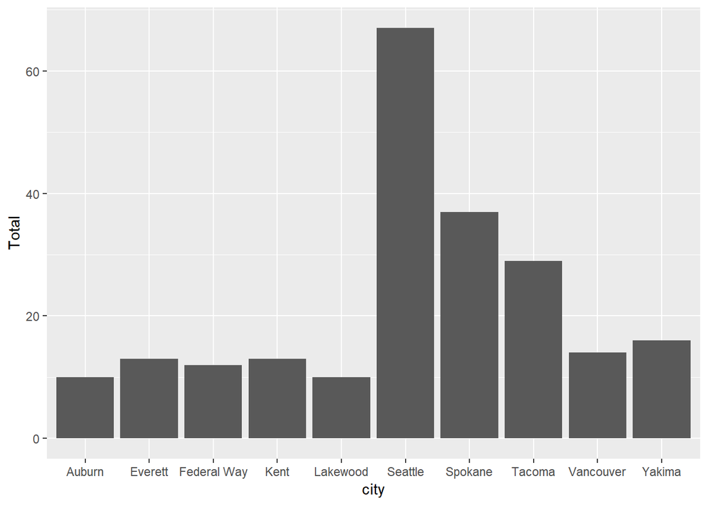

The above bar graph shows a comparison of the 10 cities with the highest counts of fatal encounters.

## Fatal Encounters over Time

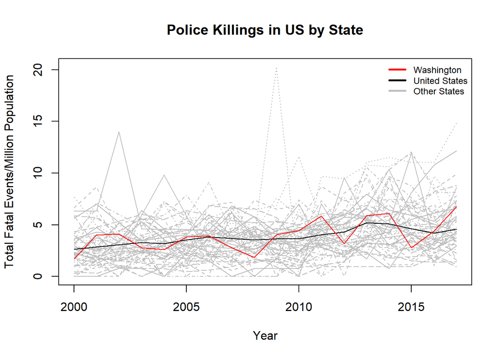

## Counts by Gender

| gender | Total |
| --- | --- |
| Male | 454 |
| Female | 28 |
| NULL | 1 |

Above is the breakdown of counts by gender, and to the right is the breakdown of counts by age group.

## Choropleth of Counties

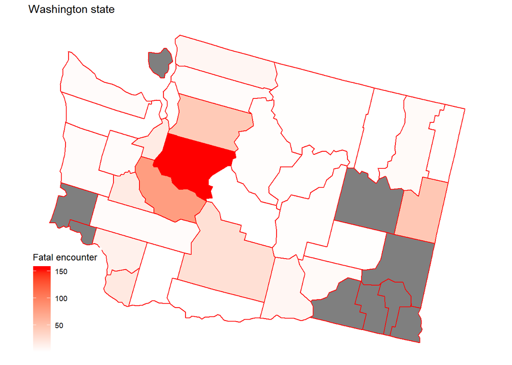

The above map shows a choropleth of total fatal encounters by county. Counties which are red have higher values while pale colored counties have lower values, and grey counties don’t have data.

## Counts by Race

| race | total |
| --- | --- |
| Race unspecified | 125 |
| African-American/Black | 51 |
| Hispanic/Latino | 27 |
| European-American/White | 242 |
| Native American/Alaskan | 20 |
| Asian/Pacific Islander | 18 |

## Counts by Age

| age | Total |
| --- | --- |
| child: 0-14 years | 1 |
| Youth: 15-24years | 76 |
| Adults :25-64 | 348 |
| Seniors : + 65years | 0 |